# Introdução ao ambiente RStudio e criação de gráficos com ggplot2

## Descrição do curso

Esse curso apresentará a linguagem de programação R, criação de funções, elaboração de gráficos e aplicações básicas em estatística. Os recursos serão trabalhados usando os pacotes dplyr e ggplot. Esta é uma introdução para aqueles que não têm experiência anterior em R e estão interessados em realizar análises exploratórias de dados.

## Objetivos

- Conhecer o progama bem como suas principais funcionalidades em problemas variados.
- Aplicar o recurso computacional em análises estatísticas (ou não).
- Aprender análises estatísticas variadas, cálculos matemáticos e produção de gráficos.

## Instalação do RStudio

Para uso do RStudio, é necessário ter instalado o R em seu computador.

Para isso, siga os passos a seguir:

- **Instalação do R**
1. Entrar no site https://www.r-project.org/
2. Clicar no menu CRAN, parte esquerda da página, escolher o espelho (mirror) Brasil.
3. Você verá que existem vários mirrors no Brasil. Escolha um, por exemplo o da Universidade Federal do Parana, no link http://cran-r.c3sl.ufpr.br/
4. Se o seu sistema operacional for Windows, clicar em Download R for Windows, subdiretório base e baixar o programa em Download R 4.0.2 for Windows
- **Instalando o RStudio**
1. Entre no site do RStudio: https://rstudio.com/.
2. No menu superior direito, clique em Products, RStudio.
3. O RStudio tem uma versão paga, mas estamos interessados na sua versão gratuita. Procure por RStudio Desktop.
4. Clique em Download RStudio Desktop, Procure a opção Free e clique em Download.
5. Escolha de acordo com o sistema operacional utilizado.
6. No caso do sistema Windows, clicar em Download RStudio for Windows.

## Unidade 1

### 1.1 Apresentação e aspectos iniciais do RStudio

https://youtu.be/BVIHTq8C2aM

```r
# exemplo1
7 * 9 + 2 * 6
```

```
## [1] 75
```

```r
2.5 * 4
```

```
## [1] 10
```

```r
(50 + 7) / (8 * (3 - 5/2))
```

```
## [1] 14.25
```

```r
3 ^ 4
```

```
## [1] 81
```

```r
# exemplo 2
x <- 15
x + 5
```

```
## [1] 20
```

```r
x * x / 2
```

```
## [1] 112.5
```

```r
2 ^ x
```

```
## [1] 32768
```

```r
y <- x / 3; y
```

```
## [1] 5
```

```r
# exemplo 3
vetor.num <- c(1, 2, 5, 8, 1001)

soma <- 0

for (item in vetor.num) {
    soma <- soma + item;
}

soma; sum(vetor.num)
```

```
## [1] 1017
```

```
## [1] 1017
```

```r
media <- soma / length(vetor.num); media; mean(vetor.num)
```

```
## [1] 203.4
```

```
## [1] 203.4
```

```r
# exemplo 4
#install.packages("fBasics")
library(fBasics)
basicStats(vetor.num)
```

```
##                 vetor.num
## nobs             5.000000
## NAs              0.000000
## Minimum          1.000000
## Maximum       1001.000000
## 1. Quartile      2.000000
## 3. Quartile      8.000000
## Mean           203.400000
## Median           5.000000
## Sum           1017.000000
## SE Mean        199.403761
## LCL Mean      -350.233597
## UCL Mean       757.033597
## Variance    198809.300000
## Stdev          445.880365
## Skewness         1.073211
## Kurtosis        -0.920121
```

```r
# exemplo 5
setwd("/home/bira/github/estudos_ciencia_de_dados/UFSCar/introducao_ambiente_RStudio_criacao_graficos_ggplot2")

dados <- read.table("dados.txt", header=TRUE)

# exemplo 6
class(dados)
```

```
## [1] "data.frame"
```

```r
str(dados)
```

```
## 'data.frame':    40 obs. of  7 variables:
##  $ Id    : int  1 2 3 4 5 6 7 8 9 10 ...
##  $ Sexo  : int  1 0 1 1 0 0 1 1 1 1 ...
##  $ Idade : int  23 24 20 20 18 19 23 21 21 22 ...
##  $ Peso  : int  62 57 73 80 70 61 89 64 65 71 ...
##  $ Altura: num  1.61 1.62 1.65 1.66 1.68 ...
##  $ Renda : int  1 2 2 3 2 2 2 2 1 1 ...
##  $ Faltas: int  1 2 0 1 2 3 0 1 2 1 ...
```

```r
head(dados)
```

```
##   Id Sexo Idade Peso Altura Renda Faltas
## 1  1    1    23   62  1.610     1      1
## 2  2    0    24   57  1.624     2      2
## 3  3    1    20   73  1.647     2      0
## 4  4    1    20   80  1.656     3      1
## 5  5    0    18   70  1.677     2      2
## 6  6    0    19   61  1.692     2      3
```

```r
tail(dados)
```

```
##    Id Sexo Idade Peso Altura Renda Faltas
## 35 35    1    26   86  1.898     2      5
## 36 36    0    27   71  1.904     3      2
## 37 37    0    27   77  1.915     2      1
## 38 38    1    18   57  1.921     2      3
## 39 39    1    24   67  1.929     2      2
## 40 40    0    25   73  1.977     2      3
```

```r
summary(dados)
```

```
##        Id             Sexo           Idade           Peso           Altura
##  Min.   : 1.00   Min.   :0.000   Min.   :18.0   Min.   :54.00   Min.   :1.610
##  1st Qu.:10.75   1st Qu.:0.000   1st Qu.:19.0   1st Qu.:65.00   1st Qu.:1.728
##  Median :20.50   Median :0.000   Median :22.0   Median :70.00   Median :1.802
##  Mean   :20.50   Mean   :0.475   Mean   :21.9   Mean   :69.58   Mean   :1.794
##  3rd Qu.:30.25   3rd Qu.:1.000   3rd Qu.:24.0   3rd Qu.:73.00   3rd Qu.:1.855
##  Max.   :40.00   Max.   :1.000   Max.   :27.0   Max.   :89.00   Max.   :1.977
##      Renda           Faltas
##  Min.   :1.000   Min.   :0.00
##  1st Qu.:1.000   1st Qu.:1.00
##  Median :2.000   Median :2.00
##  Mean   :1.925   Mean   :1.65
##  3rd Qu.:2.000   3rd Qu.:2.00
##  Max.   :3.000   Max.   :5.00
```

```r
head(dados$Idade)
```

```
## [1] 23 24 20 20 18 19
```

### 1.2 Manipulando dados

https://youtu.be/phMNriJholM

### 1.3 Estruturas de fluxo

https://youtu.be/zsnD8QxTip0

### 1.4 Aspectos gerais sobre criação de funções no RStudio

https://youtu.be/mAFV-x2Zbys

### 1.5 Manipulando dados com o pacote dplyr

https://youtu.be/JPzw0cy5l9k

## Unidade 2

### 2.1 Primeiros passos com o pacote ggplot2

https://youtu.be/XeKg3cHC1eE

### 2.2 Subplots, gráfico de barras, histogramas, polígono de frequência e boxplots

https://youtu.be/YEJH24TrXsY

## Questionário

Questão 1: Uma organização de teste de produtos de consumo queria comparar o consumo de energia anual de cinco marcas diferentes de umidificador. Pelo fato de o consumo de energia depender do nível de umidade prevalecente, decidiu-se monitorar cada marca em quatro níveis diferentes de umidade, do moderado ao alto (portanto, dispondo em blocos o nível de umidade). Dentro de cada nível, as marcas foram atribuídas aleatoriamente aos cinco locais selecionados. As observações resultantes (kwh anuais) aparecem na tabela.

### Tabela 1 - Dados do consumo de força

[output not shown]

Para ler os dados da Tabela 1 no RStudio, pode-se criar um arquivo do tipo txt com três colunas e nomeado por dados. A primeira coluna ser nomeada de marcas, a segunda de umidade e a terceira de consumo. Com base na Tabela 1, do arquivo dados e utilizando as funcionalidades do pacote dplyr, assinale a alternativa falsa.

- Arquivo dados.txt

```bash
marcas;umidade;consumo
A;1;685
A;2;792
A;3;838
A;4;875
B;1;722
B;2;806
B;3;893
B;4;953
C;1;733
C;2;802
C;3;880
C;4;951
D;1;811
D;2;888
D;3;952
D;4;1005
E;1;828
E;2;920
E;3;978
E;4;1023
```

```r
# carregar o pacote dplyr
library(dplyr)
# ler o arquivo dados.txt
dados <- read.table("./questionario/dados.txt", header=TRUE, sep = ";")

# visualizar od primeiros dados
head(dados)
```

```
##   marcas umidade consumo
## 1      A       1     685
## 2      A       2     792
## 3      A       3     838
## 4      A       4     875
## 5      B       1     722
## 6      B       2     806
```

```r
# A média do consumo de cada nível de umidade pode ser fornecida pelos comandos
media = dados %>% group_by(umidade) %>% summarise(dados_media = mean(consumo)); media
```

```
## # A tibble: 4 × 2
##   umidade dados_media
##     <int>       <dbl>
## 1       1        756.
## 2       2        842.
## 3       3        908.
## 4       4        961.
```

```r
# A média do consumo pode ser fornecida pelos comandos
media = dados %>% summarise(dados_media = mean(consumo)); media
```

```
##   dados_media
## 1      866.75
```

```r
# A média do consumo de cada marca de umidificador pode ser fornecida pelos comandos
media = dados %>% group_by(marcas) %>% summarise(dados_media = mean(consumo)); media
```

```
## # A tibble: 5 × 2
##   marcas dados_media
##   <chr>        <dbl>
## 1 A             798.
## 2 B             844.
## 3 C             842.
## 4 D             914
## 5 E             937.
```

```r
# A média do consumo de cada marca de umidificador pode ser fornecida pelos comandos
media = dados %>% summarise(dados_media = mean(consumo)); media
```

```
##   dados_media
## 1      866.75
```

```r
# A média, total, mínimo, máximo e desvio-padrão do consumo de cada marca de umidificador podem ser fornecidos pelos comandos
res = dados %>% group_by(marcas) %>% summarise(media = mean(consumo),
                                               total = sum(consumo),
                                               min = min(consumo),
                                               max = max(consumo),
                                               dp = sd(consumo)); res
```

```
## # A tibble: 5 × 6
##   marcas media total   min   max    dp
##   <chr>  <dbl> <int> <int> <int> <dbl>
## 1 A       798.  3190   685   875  82.3
## 2 B       844.  3374   722   953 101.
## 3 C       842.  3366   733   951  94.5
## 4 D       914   3656   811  1005  83.7
## 5 E       937.  3749   828  1023  84.2
```

Questão 2: Qual dos scripts a seguir faz a seguinte tarefa: por meio de uma função, o programa recebe o registro de velocidade de um carro. Se ele ultrapassar 80 km/h, mostra uma mensagem dizendo que ele foi multado. A multa vai custar R$7,00 por cada km/h acima do limite. Se ele não ultrapassar 80 km/h, exibe a mensagem de que o limite de velocidade foi respeitado.

```r
radar=function(vel) {
  if(vel > 80){
    u = vel - 80
    multa = 7 * u
    return(list(Situação = "Multado", Valor_da_multa = multa))
  }
  if(vel >= 0 & vel <= 80)
    print("Parabéns, você respeitou o limite de velocidade")
}
```

Questão 3: Em relação às funções dos pacotes “dplyr”, assinale a alternativa correta:

1. A função “arrange()” exibe informações do data.set, como quantidade de linhas e o tipo das variáveis. **b) A função “mutate()” permite criar uma nova coluna, com base em dados de outras colunas.**
2. A função “select()” é utilizada para filtrar as linhas de um data.set.
3. A função “summarise()” é utilizada para ordenar os dados de um data.set.
4. A função “group_by()” faz operações de agregação de linhas limitadas a uma determinada subdivisão do conjunto de dados.

Questão 4: A respeito das funções utilizadas na manipulação de dados na linguagem R, assinale a alternativa correta:

1. Pacotes são conjuntos extras de funções do R que podem ser instalados. Quando se deseja utilizar, pela primeira vez, uma função que requer o uso de um determinado pacote basta executar o comando library.
2. Todas as operações executadas na linguagem R com o pacote dplyr exigem a adição do operador %>% ao final da função.
3. Em aplicações com data.frame, a notação [,] é utilizada para subdividir a tabela. Com uma vírgula separando qual a coluna (posição antes da vírgula) e a linha (posição após a vírgula) que se deseja selecionar.
4. Para remover uma coluna de uma seleção, usa-se a função “select()” com o nome da coluna e o sinal de divisão. **e) O “dplyr” é um pacote que permite selecionar e manipular os data frames.**

Questão 5: Acerca da linguagem de programação R e programa RStudio, assinale a alternativa correta:

1. O RStudio possui uma interface gráfica que complica o uso da linguagem R na manipulação de dados, na criação de gráficos e nos cálculos estatísticos. **b) A linguagem R é uma linguagem de programação usada para análise estatística e produção de gráficos. Uma das suas vantagens é a linguagem acessível, fator que facilita a sua usabilidade.**
2. A linguagem R é um software livre de ambiente de desenvolvimento integrado para RStudio.
3. O RStudio é dividido em três janelas: “Editor de código”, “Console” e “Environment”.
4. Ao executar o arquivo de instalação da linguagem R, não é permitido ao usuário escolher o idioma do instalador.

Questão 6: Com relação ao pacote ggplot2, assinale a alternativa falsa:

**a) Para se fazer um gráfico de barras com múltiplos fatores por meio do pacote ggplot2 é preciso somar a camada geom_col() à do ggplot.** b) Para se fazer um gráfico de barras com o ggplot2 é preciso somar a camada geom_bar() à do ggplot. c) Permite a criação mais sofisticada de gráficos no R e RStudio por meio da adição de camadas a um mesmo gráfico com o operador “+”. d) Para se fazer um histograma por meio do pacote ggplot2 é preciso somar a camada geom_freqpoly() à do ggplot. e) Para se fazer um diagrama de dispersão (ou gráfico de pontos) com o ggplot2 é preciso somar a camada geom_point() à do ggplot.

Questão 7: Imagine a seguinte situação: você está trabalhando com análise de dados no R e surge uma dúvida sobre qualquer função ou parâmetro.

A partir desse problema, assinale a alternativa que apresenta o procedimento para consultar a documentação da função:

1. Utilizar o ponto de interrogação antes do nome da função. Em seguida, a documentação será aberta na aba “Files”.
2. Inserir o ponto de exclamação antes do nome da função. Em seguida, a documentação será aberta na aba “Help”.
3. Após a devida aplicação da função, a documentação será aberta na aba “Plots”.
4. Inserir o ponto de interrogação antes do nome da função.
5. Inserir o caractere asterisco antes do nome da função.

Questão 8: Considere o arquivo de dados “Tab1modificado.txt” (apresentado em aula), que traz informações sobre a identificação do aluno (Id), do sexo, idade, peso, altura e renda (Baixa, Média e Alta) e número de faltas de 40 alunos de uma em uma universidade.

Após carregar o conjunto de dados por meio do objeto dados e utilizando os recursos do pacote ggplot2, qual alternativa reproduz o gráfico a seguir.

```r
# carregar o pacote dplyr
library(dplyr)
library(ggplot2)

# ler o arquivo dados.txt
dados <- read.table("./questionario/Tab1modificado.txt", header=TRUE)

y=dados$Altura

k=round(sqrt(length(y))); k
```

```
## [1] 6
```

```r
A=max(y)-min(y); A
```

```
## [1] 0.367
```

```r
c=round(A/(k-1),2); c
```

```
## [1] 0.07
```

```r
LI1=round(min(y) - c/2, 2); LI1
```

```
## [1] 1.58
```

```r
LSk=round(max(y) + c/2, 2); LSk
```

```
## [1] 2.01
```

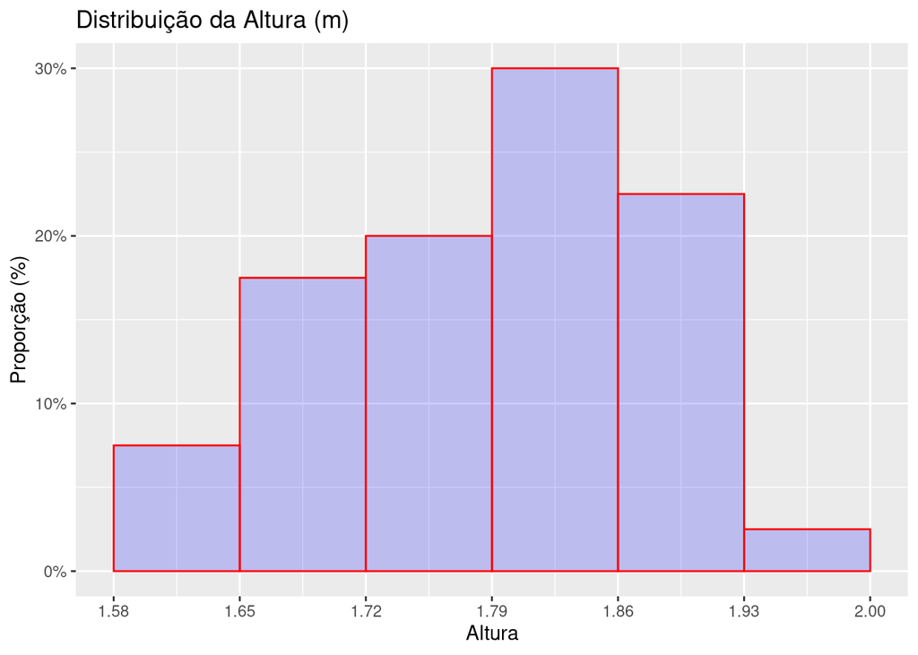

```r
ggplot(data=dados, aes(Altura)) +

  geom_histogram(aes(y =..count../sum(..count..)),

                 breaks=seq(LI1, LSk, by = c),

                 col="red",

                 fill="blue",

                 alpha=.2) +

  labs(title = "Distribuição da Altura (m)",

       x = "Altura",

       y = "Proporção (%)") +

  scale_x_continuous(name = "Altura",

                     breaks = seq(LI1, LSk, by = c)) +

  scale_y_continuous(labels = scales::percent_format())
```

Questão 9: O RStudio possui diversas abas com diferentes funcionalidades. Assinale a alternativa que relaciona a descrição mais adequada para a atividade citada:

**a) A janela que exibe os objetos armazenados na memória é a “Environment”.** b) “Environment” é a janela que exibe o resultado do que é executado no “Editor de códigos”. c) A aba “Packages” é o local onde os gráficos gerados são exibidos. d) A aba “Plots” exibe a documentação de uma determinada função ou pacote quando a função “help()” é executada. e) A aba “Files” exibe os gráficos do RStudio.

Questão 10: Sobre a janela “Console”, assinale a alternativa que descreve as suas funcionalidades:

1. Exibe objetos que estão carregados na memória.
2. Permite instalar, atualizar e pesquisar os pacotes.
3. Exibe a estrutura de arquivos do projeto, além de remover ou salvar os objetos. **d) Expressa o resultado das ações realizadas na janela “Editor de códigos”.**
4. É o local para escrever, salvar e editar o código.

## Referências

- ALBERT, J. Bayesian Computation with R, Springer., 2007.
- CLAUDE, J. Morphometrics with R, Springer, 2008.
- COOK, D.; SWAYNE, D. F. Interactive and Dynamic Graphics for Data Analysis with R, Springer, 2007.
- CRAWLEY, M. J. The R Book, John Wiley & Sons Ltd, 2007.
- HENRY, M.; STEVENS, H. A Primer of Ecology with R, Springer, 2009.
- OLIVEIRA, P. F.; GUERRA, S.; MCDONNELL, R. Ciência de Dados com R: Introdução. Brasília: Editora IBPAD, 2018.
- R CORE TEAM (2019). R: A language and environment for statistical computing, R Foundation for Statistical Computing, Vienna, Austria. Disponível em https://www.R-project.org/;. Acesso em: 18 nov. 2022.
- ROBERT, C. P.; CASELLA, G. Introducing Monte Carlo Methods with R, Springer, 2010.
- SOETAERT, K.; CASH, J.; MAZZIA, F. Solving differential equation in R. Springer, 2012.
- TATTAR, P. N.; RAMAIAH, S.; MANJUNATH, B. G. A course in Statistics with R, John Wiley & Sons, 2016.
- VANCE A. Data Analysts Captivated by R’s Power. Disponível em: http://www.nytimes.com/2009/01/07/technology/business-computing/07program.html?_r=0;. Acesso em: 18 nov. 2022.
- VERZANI, J. Getting Started with RStudio, O’Reilly Media, Inc., 2011.
- WICKHAM, H. ggplot2: Elegant Graphics for Data Analysis, Springer, 2009.